# Praca domowa 2

Aleksandra Zawadka

## Dane

Dane wykorzystane w Pracy domowej 2 opisują wycenę nieruchmości. Każda obserwacja jest pewną nieruchmością, która posiada informacje takie jak powierzchnia, liczba pokoi, liczba łazienek i wiele więcj. Opis wszystkich kolumn w pliku `README.md`.

## Zadanie 1

Jak wygląda rozkład ceny nieruchomości w poszczególnych kodach pocztowych na przestrzeni lat? Rozważamy kody pocztowe, które mają więcej niż 280 posiadłości.

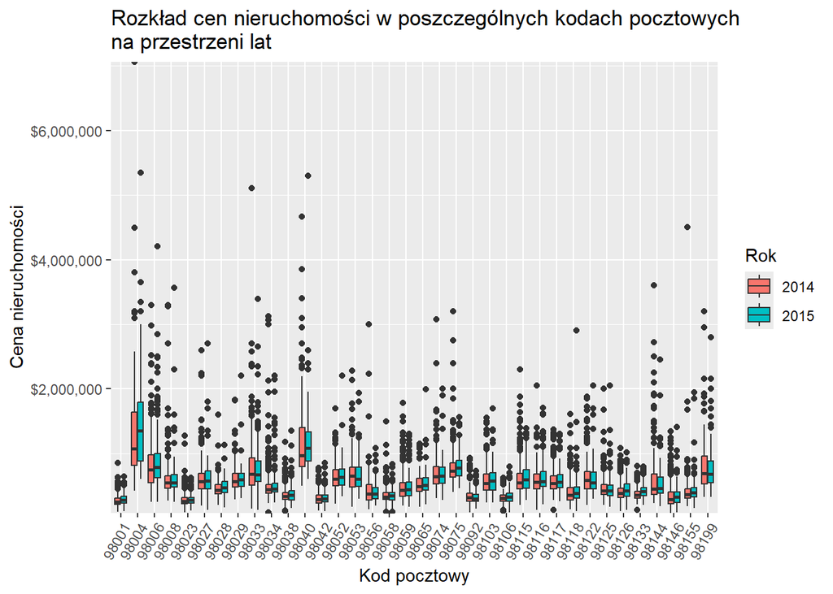

```r
# Tu umieść kod do wygenerowania odpowiedzi do zadania.
df1 <- df %>%
  group_by(zipcode) %>%
  filter(n() > 280) %>%
  mutate(year = as.numeric(substr(date, 1, 4)))

plot1 <- ggplot(df1, aes(x = factor(zipcode), y = price, fill = factor(year))) +
  geom_boxplot() +
  labs(title = "Rozkład cen nieruchomości w poszczególnych kodach pocztowych \nna przestrzeni lat",
       x = "Kod pocztowy",
       y = "Cena nieruchomości",
       fill = "Rok") +
  scale_y_continuous(labels = dollar, expand = c(0, 0)) +
  theme(axis.text.x = element_text(angle = 60, vjust = 1, hjust = 1))
plot1
```

**Komentarz:** Z wykresu widzimy, że w 2015 roku w porównaniu do 2014 ceny nieruchomości w poszczególnych kodach pocztowych nie zmieniły się znacząco (lekko wzrosły). Natomiast ceny różnią się w zależności od kodu, najwyższe są osiągane dla 98004

## Zadanie 2

Czy jest różnica w rozkładzie ceny nierchomości od powierzchni mieszkalnej uwzględniając podział na nieruchomości z piwnicą i bez?

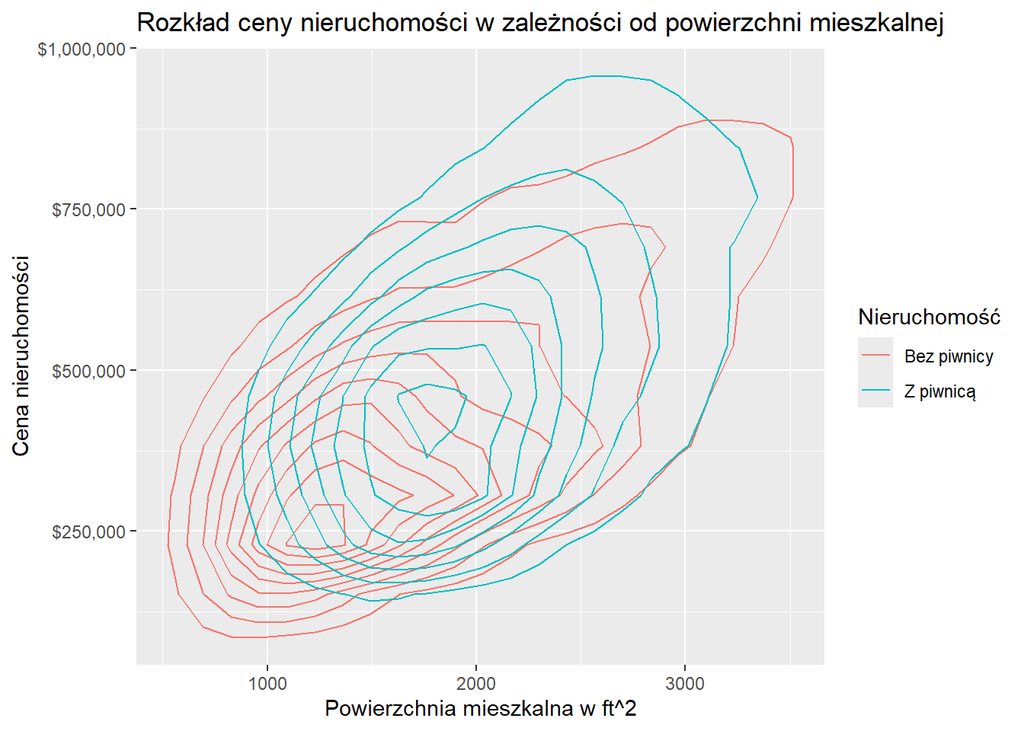

```r
# Tu umieść kod do wygenerowania odpowiedzi do zadania.
df2 <- df %>%
  mutate(basement = ifelse(sqft_basement > 0, "Z piwnicą", "Bez piwnicy"))

plot2 <- ggplot(df2, aes(x = sqft_living, y = price, color = basement)) +
  geom_density_2d(bins = 10) + scale_y_continuous(labels = dollar) +
  labs(title = "Rozkład ceny nieruchomości w zależności od powierzchni mieszkalnej",
       x = "Powierzchnia mieszkalna w ft^2",
       y = "Cena nieruchomości",
       color = "Nieruchomość")
plot2
```

**Komentarz:** Z wykresu widzimy, że ceny nieruchości z piwnicą osiągają nieco wyższe ceny. Można też zauważyć, że nieruchomości bez piwnicy są dostępne w mniejszych powierzniach.

## Zadanie 3

Jaka jest zależność pomiędzy jakością wykończenia nieruchomości a liczbą pięter?

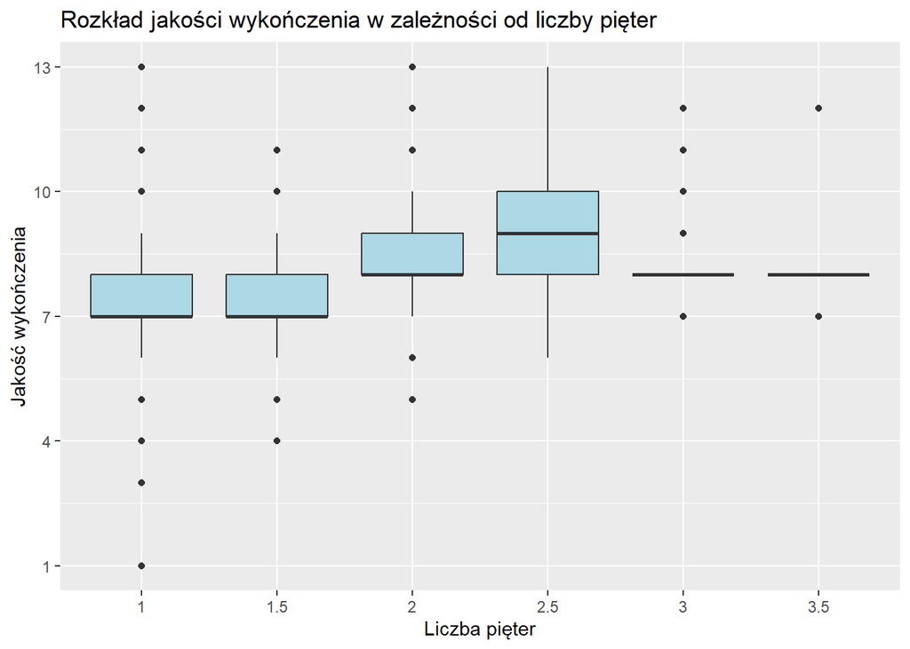

```r
# Tu umieść kod do wygenerowania odpowiedzi do zadania.
df3 <- df %>%
  group_by(floors) %>%
  summarise(sum=n())

plot3 <- ggplot(df, aes(x = as.factor(floors), y = grade)) +
  geom_boxplot(fill = "lightblue") +
  labs(title = "Rozkład jakości wykończenia w zależności od liczby pięter",
       x = "Liczba pięter",
       y = "Jakość wykończenia") +
  scale_y_continuous(breaks = seq(min(df$grade), max(df$grade), by = 3))
plot3
```

**Komentarz:** Z wykresu widać, że najwyższa mediana jakości wykończenia jest osiągana dla liczby pięter 2.5. Od 1 do 2.5 piętra jakość wykończenia rośnie wraz z ilością pięter a od 2.5 do 3.5 maleje, ale dalej jest wyższa od 1 i 1.5 piętra.

## Zadanie 4

Jaka jest zależność między powierzchnią mieszkalną nieruchomości a powierzchnią gruntu w podziale na liczbę sypialni?

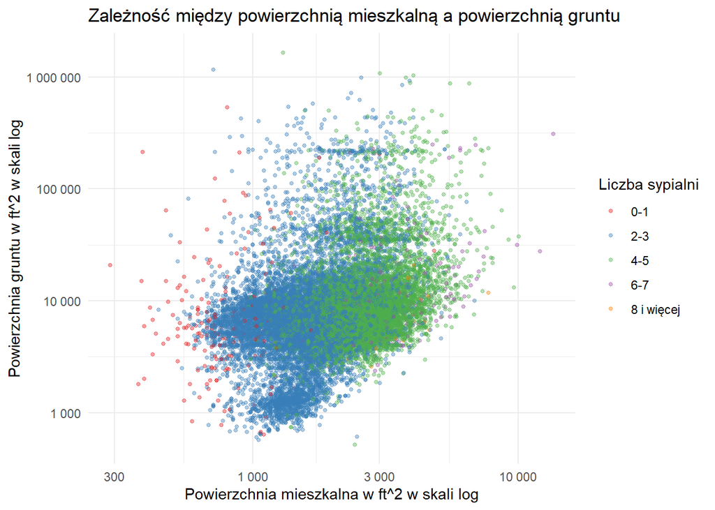

```r
# Tu umieść kod do wygenerowania odpowiedzi do zadania.
df4 <- df %>% mutate(ilosc_syp = case_when(
  bedrooms <=1 ~ "0-1",
  bedrooms <=3 ~ "2-3",
  bedrooms <=5 ~ "4-5",
  bedrooms <=7 ~ "6-7",
  bedrooms >=8 ~ "8 i więcej"
))
df4$ilosc_syp <- factor(df4$ilosc_syp, levels = c("0-1","2-3","4-5","6-7","8 i więcej"))

plot4 <- ggplot(df4, aes(x = sqft_living, y = sqft_lot, color = ilosc_syp)) +
  geom_point(alpha = 0.4, size = 1) +
  labs(title = "Zależność między powierzchnią mieszkalną a powierzchnią gruntu",
       x = "Powierzchnia mieszkalna w ft^2 w skali log",
       y = "Powierzchnia gruntu w ft^2 w skali log",
       color = "Liczba sypialni") +
  scale_color_brewer(palette = "Set1") +
  scale_x_log10(labels = label_number(scale = 1)) +
  scale_y_log10(labels = label_number(scale = 1)) +
  theme_minimal()
plot4
```

**Komentarz:** Z wykresu widać, że powierzchnia mieszkalna rośnie wraz z powierzchnią gruntu. Można też zauważyć, że im więcej sypialni, tym większa jest powierznia mieszkalna i najwięcej jest nieruchomości, które mają od 2 do 5 sypialni.

## Zadanie 5

Rozważmy tylko nieruchomości, które miały remont. W której dekadzie było najwięcej przeprowadzonych remontów? Czy w poszczególnych dekadach jest porównywalny procent nieruchmości dla każdej wartości miary jakości i wykończenia nieruchomości?

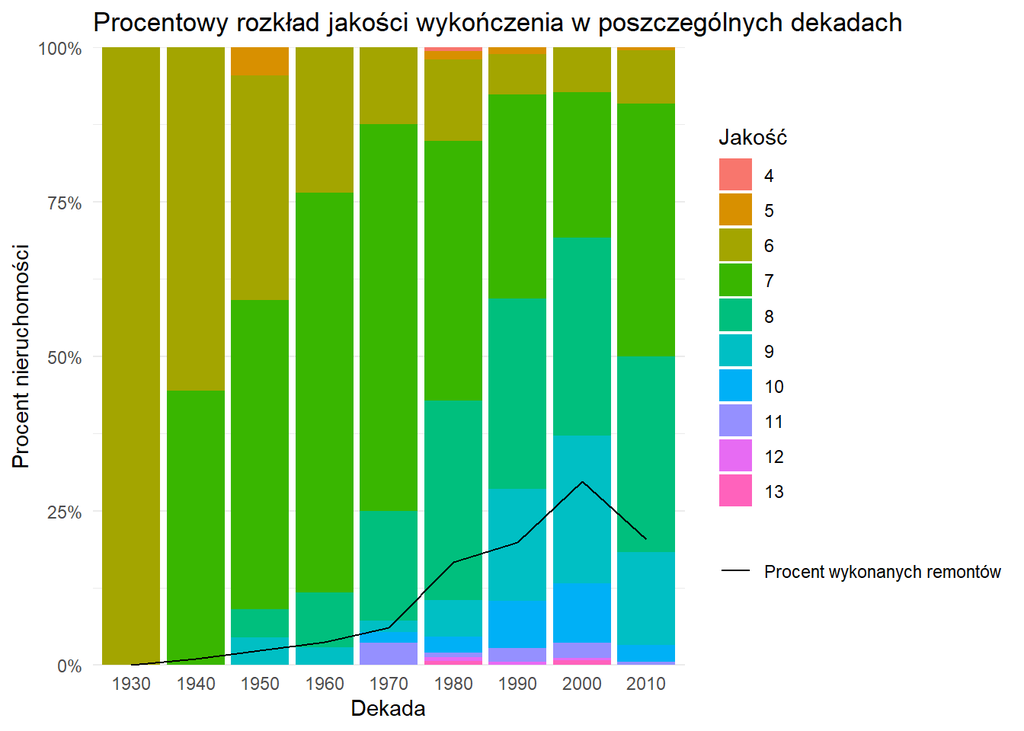

```r
# Tu umieść kod do wygenerowania odpowiedzi do zadania.
df5 <- df %>%
  filter(yr_renovated > 0) %>%
  mutate(decade = floor(yr_renovated / 10) * 10)

quality_percentage <- df5 %>%
  group_by(decade, grade) %>%
  summarise(count = n()) %>%
  mutate(percentage = count / sum(count) * 100)

renovate_percentage <- df5 %>%
  group_by(decade) %>%
  summarise(total = n()) %>%
  mutate(total_per = total / sum(total)*100)

plot5 <- ggplot() +
  geom_bar(data = quality_percentage, aes(x = as.factor(decade), y = percentage, fill = as.factor(grade)),
           stat = "identity", position = "fill") +
  geom_line(data = renovate_percentage, aes(x = as.factor(decade), y = total_per / 100, linetype = "Procent wykonanych remontów"),
            group = 1, color = "black", linewidth = 0.5) +
  labs(title = "Procentowy rozkład jakości wykończenia w poszczególnych dekadach",
       x = "Dekada",
       y = "Procent nieruchomości",
       fill = "Jakość") +
  theme_minimal() +
  scale_y_continuous(expand = c(0, 0), labels = percent_format()) +
  scale_linetype_manual(values = "solid", guide = guide_legend(title = NULL)) +
  theme(legend.position = "right")
plot5
```

**Komentarz:** Najwięcej remontów wykonano w dekadzie 2000. Widzimy, że jakość wykończenia rosła wraz z ilością wykonanych remontów aż do dekady 2010 gdzie ilość remontów się zmniejszyła i pogorszyła się też jakość wykończenia.

## Zadanie 6

Jak prezentuje się wartość minimalna, średnia i maksymalna ceny nieruchmości w podziele na rok budowy nieruchomości.

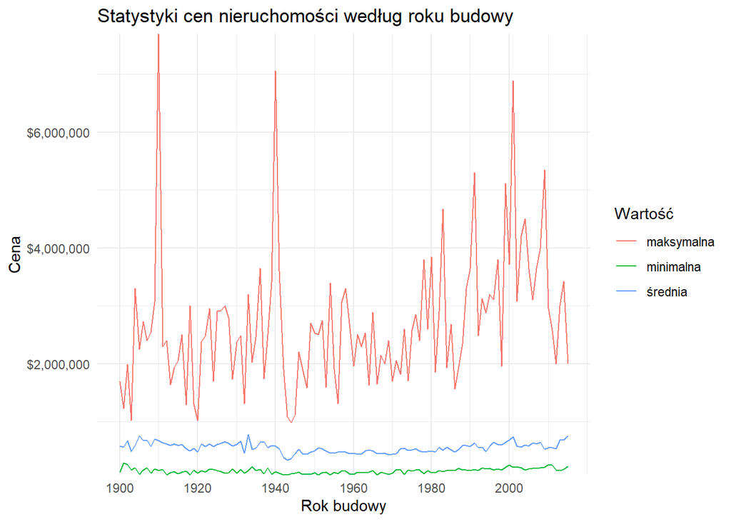

```r
# Tu umieść kod do wygenerowania odpowiedzi do zadania.
df6 <- df %>%
  group_by(yr_built) %>%
  summarise(
    min_price = min(price),
    avg_price = mean(price),
    max_price = max(price),
    count = n()
  ) %>%
  arrange(yr_built)

plot6 <- ggplot(df6, aes(x = yr_built)) +
  geom_line(aes(y = min_price, color = "minimalna")) +
  geom_line(aes(y = avg_price, color = "średnia")) +
  geom_line(aes(y = max_price, color = "maksymalna")) +
  labs(title = "Statystyki cen nieruchomości według roku budowy",
       x = "Rok budowy",
       y = "Cena",
       color = "Wartość") +
  theme_minimal()+
  scale_y_continuous(expand = c(0,0), labels = dollar_format())+
  scale_x_continuous(breaks = seq(min(df6$yr_built), max(df6$yr_built), by = 20))

plot6
```

**Komentarz:** Wartość minimalna pozostaje w miarę na takim samym poziomie przez wszystkie lata. Wartość średnia spadła około roku 1945. Potem widać wzrost, ale nie są to duże zmiany. Wartość maksymalna jest najbardziej zróżnicowana. Widać duży spadek około roku 1945. Potem zaczyna rosnąć a po 2000 roku znowu spada. Widoczne są gwałtowne wzrosty w roku 1910, 1940 i 2000.